# Renny_Oyelahan_Project_03

### Let's compare `Mortgage` versus `Income`

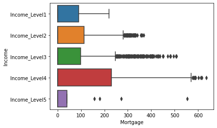

```python
sns.boxplot(data=pd.DataFrame,x='Mortgage',y='Income')
plt.show()
```

**Observations**

- Customers with `Income_Level4` took on the most `Mortgage` of all the different income levels.

### Let's compare `Personal_Loan` versus `Income`

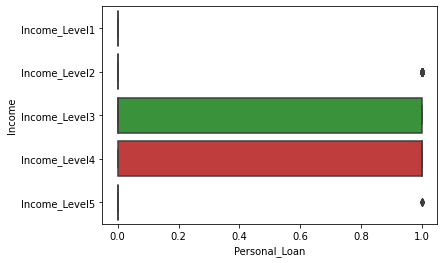

```python
sns.boxplot(data=pd.DataFrame,x='Personal_Loan',y='Income')
plt.show()
```

**Observations**

- Customers with `Income_Level3` and `Income_Level4` are more likely to take on a `Personal_Loan`.

### Data Preprocessing with the original data set

ID was dropped earlier

**Let's also drop ZipCode. It has little to no correlation to any of the other attributes**

```python
df.drop(['ZIPCode'],axis=1,inplace=True)
```

**Let's double check info to make sure ZipCode was dropped.**

```python
df.info()
```

```
<class 'pandas.core.frame.DataFrame'>
RangeIndex: 5000 entries, 0 to 4999
Data columns (total 12 columns):
 #   Column              Non-Null Count  Dtype
---  ------              --------------  -----
 0   Age                 5000 non-null   int64
 1   Experience          5000 non-null   int64
 2   Income              5000 non-null   int64
 3   Family              5000 non-null   int64
 4   CCAvg               5000 non-null   float64
 5   Education           5000 non-null   int64
 6   Mortgage            5000 non-null   int64
 7   Personal_Loan       5000 non-null   int64
 8   Securities_Account  5000 non-null   int64
 9   CD_Account          5000 non-null   int64
 10  Online              5000 non-null   int64
 11  CreditCard          5000 non-null   int64
dtypes: float64(1), int64(11)
memory usage: 468.9 KB
```

**Let's check the summary of the Income column**

```python
df['Income'].describe()
```

```
count    5000.000000
mean       73.774200
std        46.033729
min         8.000000
25%        39.000000
50%        64.000000
75%        98.000000
max       224.000000
Name: Income, dtype: float64
```

**Outlier detection and treatment**

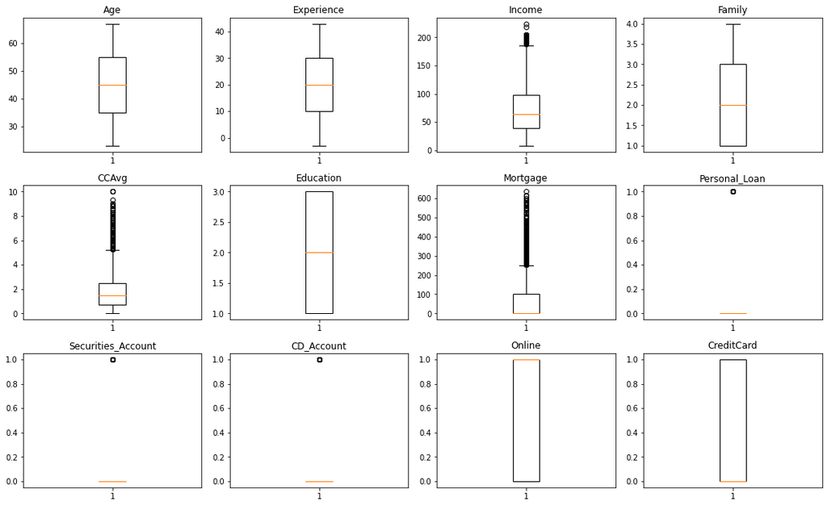

```python
# outlier detection using boxplot
# selecting the numerical columns of data and adding their names in a list
numeric_columns = ['Age', 'Experience', 'Income', 'Family', 'CCAvg', 'Education','Mortgage',
                   'Personal_Loan', 'Securities_Account', 'CD_Account', 'Online', 'CreditCard']
plt.figure(figsize=(15, 12))

for i, variable in enumerate(numeric_columns):
    plt.subplot(4, 4, i + 1)
    plt.boxplot(df[variable], whis=1.5)
    plt.tight_layout()
    plt.title(variable)

plt.show()
```

- Income, CCAvg, and Mortgage have outliers
- These outliers will not be treated because it is not out of the ordinary to spend $10,000 per month in credit card spending, to make over $200,000 per annum and to have a mortgage of $600,000

**Creating training and test sets.**

```python
# Let's choose if the customer took on a persoanl loan during the last campaign as the dependent variable
X = df.drop(["Personal_Loan"], axis=1)
Y = df["Personal_Loan"]

# Splitting data in train and test sets
X_train, X_test, y_train, y_test = train_test_split(
    X, Y, test_size=0.30, random_state=1
)
```

```python
print("Shape of Training set : ", X_train.shape)
print("Shape of test set : ", X_test.shape)
print("Percentage of classes in training set:")
print(y_train.value_counts(normalize=True))
print("Percentage of classes in test set:")
print(y_test.value_counts(normalize=True))
```

```
Shape of Training set :  (3500, 11)
Shape of test set :  (1500, 11)
Percentage of classes in training set:
0    0.905429
1    0.094571
Name: Personal_Loan, dtype: float64
Percentage of classes in test set:
0    0.900667
1    0.099333
Name: Personal_Loan, dtype: float64
```

**Observations**

- There are 3500 rows and 11 columns in the training set.
- There are 1500 rows and 11 columns in the test set.
- About 91% in the training set did not take on a personal loan during the last campaign and about 9% in the training set took out a personal loan during the last campaign.
- About 90% in the test set did not take on a personal loan during the last campaign and about 10% in the test set took out a personal loan during the last campaign.

### Model evaluation criterion

### Model can make wrong predictions as:

1. Predicting a customer is more likely to take a loan but in reality the person does not want to take a loan.
2. Predicting a customer is not interested in taking a loan, but in reality the persone would have taken a loan.

### Which case is more important?

- The bank is more interested in finding out which customers want to take a loan, so it is more important to minimize False Negatives.
- Besides, if a customer is wrongly labeled as interested in taking a loan and they turn out not to be interested, it would not be a major loss to the bank.

### How to reduce this loss i.e need to reduce False Negatives?

- The bank would want to reduce false negatives, this can be done by maximizing the Recall. Greater the recall lesser the chances of false negatives.

#### First, let's create functions to calculate different metrics and confusion matrix so that we don't have to use the same code repeatedly for each model.

- The model_performance_classification_sklearn_with_threshold function will be used to check the model performance of models.
- The confusion_matrix_sklearn_with_threshold function will be used to plot confusion matrix.

```python
# defining a function to compute different metrics to check performance of a classification model built using sklearn

def model_performance_classification_sklearn_with_threshold(model, predictors, target, threshold=0.5):
    """
    Function to compute different metrics, based on the threshold specified, to check classification model performance

    model: classifier
    predictors: independent variables
    target: dependent variable
    threshold: threshold for classifying the observation as class 1
    """

    # predicting using the independent variables
    pred_prob = model.predict_proba(predictors)[:, 1]
    pred_thres = pred_prob > threshold
    pred = np.round(pred_thres)

    acc = accuracy_score(target, pred)  # to compute Accuracy
    recall = recall_score(target, pred)  # to compute Recall
    precision = precision_score(target, pred)  # to compute Precision
    f1 = f1_score(target, pred)  # to compute F1-score

    # creating a dataframe of metrics
    df_perf = pd.DataFrame(
        {
            "Accuracy": acc,
            "Recall": recall,
            "Precision": precision,
            "F1": f1,
        },
        index=[0],
    )

    return df_perf
```

```python
# defining a function to plot the confusion_matrix of a classification model built using sklearn
def confusion_matrix_sklearn_with_threshold(model, predictors, target, threshold=0.5):
    """
    To plot the confusion_matrix, based on the threshold specified, with percentages

    model: classifier
    predictors: independent variables
    target: dependent variable
    threshold: threshold for classifying the observation as class 1
    """
    pred_prob = model.predict_proba(predictors)[:, 1]
    pred_thres = pred_prob > threshold
    y_pred = np.round(pred_thres)

    cm = confusion_matrix(target, y_pred)
    labels = np.asarray(
        [
            ["{0:0.0f}".format(item) + "\n{0:.2%}".format(item / cm.flatten().sum())]
            for item in cm.flatten()
        ]
    ).reshape(2, 2)

    plt.figure(figsize=(6, 4))
    sns.heatmap(cm, annot=labels, fmt="")
    plt.ylabel("True label")
    plt.xlabel("Predicted label")
```

### Logistic Regression

```python
# There are different solvers available in Sklearn logistic regression
# The newton-cg solver is faster for high-dimensional data

model = LogisticRegression(solver="newton-cg", random_state=1)
lg = model.fit(X_train, y_train)
```

### Finding the coefficients

```python
log_odds = lg.coef_[0]
pd.DataFrame(log_odds, X_train.columns, columns=["coef"]).T
```

|  | Age | Experience | Income | Family | CCAvg | Education | Mortgage | Securities_Account | CD_Account | Online | CreditCard |
| --- | --- | --- | --- | --- | --- | --- | --- | --- | --- | --- | --- |
| coef | -0.046774 | 0.052362 | 0.052369 | 0.713277 | 0.168456 | 1.675443 | 0.000788 | -0.841914 | 3.255627 | -0.532398 | -0.950065 |

### Converting coefficients to odds

- The coefficients of the logistic regression model are in terms of log(odd), to find the odds we have to take the exponential of the coefficients.
- Therefore, **odds = exp(b)**
- The percentage change in odds is given as **odds = (exp(b) - 1) * 100**

**Odds from coefficients**

```python
# converting coefficients to odds
odds = np.exp(lg.coef_[0])

# finding the percentage change
perc_change_odds = (np.exp(lg.coef_[0]) - 1) * 100

# removing limit from number of columns to display
pd.set_option("display.max_columns", None)

# adding the odds to a dataframe
pd.DataFrame({"Odds": odds, "Change_odd%": perc_change_odds}, index=X_train.columns).T
```

|  | Age | Experience | Income | Family | CCAvg | Education | Mortgage | Securities_Account | CD_Account | Online | CreditCard |
| --- | --- | --- | --- | --- | --- | --- | --- | --- | --- | --- | --- |
| Odds | 0.954303 | 1.053757 | 1.053764 | 2.040668 | 1.183477 | 5.341162 | 1.000788 | 0.430885 | 25.935872 | 0.587195 | 0.386716 |
| Change_odd% | -4.569700 | 5.375679 | 5.376425 | 104.066778 | 18.347652 | 434.116239 | 0.078835 | -56.911482 | 2493.587168 | -41.280500 | -61.328430 |

### Coefficient interpretations

- `Age`: Holding all other features constant a unit change in Age will decrease the odds of a customer taking a personal loan by 0.95 times or a 4.56% decrease in the odds.
- `Experience`: Holding all other features constant a unit change in Experience will increase the odds of a customer taking a personal loan by 1.05 times or a 5.38% increase in the odds.
- `Income`: Holding all other features constant a unit change in Income will increase the odds of a customer taking a personal loan by 1.05 times or a 5.38% increase in the odds.
- `Family`: Holding all other features constant a unit change in Family size will increase the odds of a customer taking a personal loan by 2.04 times or a 104.07% increase in the odds.
- `CCAvg`: Holding all other features constant a unit change in CCAvg will increase the odds of a customer taking a personal loan by 1.18 times or a 18.34% increase in the odds.
- `Education`: Holding all other features constant a unit change in Education will increase the odds of a customer taking a personal loan by 5.34 times or a 434.12% increase in the odds.
- `Mortgage`: Holding all other features constant a unit change in Mortgage will increase the odds of a customer taking a personal loan by 1.00 times or a 0.08% increase in the odds.
- `Securities_Account`: Holding all other features constant a unit change in securities account will decrease the odds of a customer taking a personal loan by 0.43 times or a 56.91% decrease in the odds.
- `CD_Account`: Holding all other features constant a unit change in CD_Account will increase the odds of a customer taking a personal loan by 25.94 times or a 2493.59% increase in the odds.
- `Online`: Holding all other features constant a unit change in online will decrease the odds of a customer taking a personal loan by 0.59 times or a 41.28% decrease in the odds.
- `CreditCard`: Holding all other features constant a unit change in CreditCard will decrease the odds of a customer taking a personal loan by 0.39 times or a 61.33% decrease in the odds.

#### Checking model performance on training set

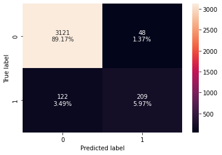

```python
# creating confusion matrix
confusion_matrix_sklearn_with_threshold(lg, X_train, y_train)
```

```python
log_reg_model_train_perf = model_performance_classification_sklearn_with_threshold(
    lg, X_train, y_train
)

print("Training performance:")
log_reg_model_train_perf
```

```
Training performance:
```

|  | Accuracy | Recall | Precision | F1 |
| --- | --- | --- | --- | --- |
| 0 | 0.951429 | 0.63142 | 0.81323 | 0.710884 |

#### ROC-AUC

- ROC-AUC on training set

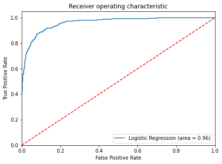

```python
logit_roc_auc_train = roc_auc_score(y_train, lg.predict_proba(X_train)[:, 1])
fpr, tpr, thresholds = roc_curve(y_train, lg.predict_proba(X_train)[:, 1])
plt.figure(figsize=(7, 5))
plt.plot(fpr, tpr, label="Logistic Regression (area = %0.2f)" % logit_roc_auc_train)
plt.plot([0, 1], [0, 1], "r--")
plt.xlim([0.0, 1.0])
plt.ylim([0.0, 1.05])
plt.xlabel("False Positive Rate")
plt.ylabel("True Positive Rate")
plt.title("Receiver operating characteristic")
plt.legend(loc="lower right")
plt.show()
```

- Logistic Regression model is giving a good performance on training set but let's see if we can get recall higher.

### Optimal threshold using AUC-ROC curve

```python
# Optimal threshold as per AUC-ROC curve
# The optimal cut off would be where tpr is high and fpr is low
fpr, tpr, thresholds = roc_curve(y_train, lg.predict_proba(X_train)[:, 1])

optimal_idx = np.argmax(tpr - fpr)
optimal_threshold_auc_roc = thresholds[optimal_idx]
print(optimal_threshold_auc_roc)
```

```
0.13320251712474884
```

#### Checking model performance on training set

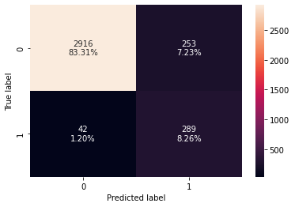

```python
# creating confusion matrix
confusion_matrix_sklearn_with_threshold(
    lg, X_train, y_train, threshold=optimal_threshold_auc_roc
)
```

```python
# checking model performance for this model
log_reg_model_train_perf_threshold_auc_roc = model_performance_classification_sklearn_with_threshold(
    lg, X_train, y_train, threshold=optimal_threshold_auc_roc
)
print("Training performance:")
log_reg_model_train_perf_threshold_auc_roc
```

```
Training performance:
```

|  | Accuracy | Recall | Precision | F1 |
| --- | --- | --- | --- | --- |
| 0 | 0.915714 | 0.873112 | 0.53321 | 0.662085 |

**Observations**